# Chlorophyll-a and SST database

Michael Sumner, Rowan Trebilco, Andrew Constable

4/24/2018

## SST and chl-a database

We built a database of summer chlorophyll-a and sea surface temperature for the Southern Ocean summarized by month.

This consists of a table of values of SST and chlor-a in a database on ACE-ecostats.

```r
## connect to the db
dp <- "/home/acebulk/data"
db <- dplyr::src_sqlite(file.path(dp, "habitat_assessment.sqlite3"))

## create a query for the table
library(dplyr)
(tab <- tbl(db, "chl_sst_25k_monthly"))
```

```
## # Source:   table<chl_sst_25k_monthly> [?? x 6]
## # Database: sqlite 3.22.0 [/home/acebulk/data/habitat_assessment.sqlite3]
##      sst   chla  cell  date  year   mon
##    <dbl>  <dbl> <int> <int> <int> <int>
##  1  27.6 0.334     60 12036  2002    12
##  2  27.6 0.122     61 12036  2002    12
##  3  27.6 0.0801    62 12036  2002    12
##  4  27.6 0.0786    63 12036  2002    12
##  5  27.6 0.0844    64 12036  2002    12
##  6  27.6 0.0930    65 12036  2002    12
##  7  27.6 0.0802    66 12036  2002    12
##  8  27.6 0.0777    67 12036  2002    12
##  9  27.7 0.0821    68 12036  2002    12
## 10  27.7 0.0917    69 12036  2002    12
## # ... with more rows
```

The `tab` object is now a live connection to the summary table, and can be used to issue queries of the data.

We can inquire directly for various metrics.

```r
## the number of total rows
tab %>% tally()
```

```
## # Source:   lazy query [?? x 1]
## # Database: sqlite 3.22.0 [/home/acebulk/data/habitat_assessment.sqlite3]
##         n
##     <int>
## 1 9587843
```

```r
## the start and end date (in days since 1970-01-01)
## convert to date format (in R after collect)
epoch <- as.Date("1970-01-01")
tab %>% summarize(start = min(date, na.rm = TRUE), end = max(date, na.rm = TRUE)) %>%
  collect(n = Inf) %>%
  mutate(start = start + epoch, end = end + epoch)
```

```
## # A tibble: 1 x 2
##   start      end
##   <date>     <date>
## 1 2002-12-15 2018-02-15
```

```r
## calculate number of non missing values

tab %>% dplyr::filter(!is.na(chla) | !is.na(sst)) %>% tally()
```

```
## # Source:   lazy query [?? x 1]
## # Database: sqlite 3.22.0 [/home/acebulk/data/habitat_assessment.sqlite3]
##         n
##     <int>
## 1 9587843
```

It is possible to re-map the data back onto its 25km grid, but we need a little bit of extra material. The grid is a Lambert Azimuthal Equal Area grid centred on the south pole. We can insert this function any that the original grid is required.

```r
default_grid <- function() {
  prjj <-         "+proj=laea +lat_0=-90 +datum=WGS84"
  raster(spex::buffer_extent(projectExtent(raster(extent(-180, 180, -90, -30),
                                                             crs = "+init=epsg:4326"),
                                                      prjj), 25000),
                    res = 25000, crs = prjj)


}
```

Now issue a query to summarize the entire data set into a grand summer mean and populate the grid.

(Be sure to collect the result of the query into memory).

```r
gmean <- tab %>% group_by(cell) %>% summarize(sst = mean(sst, na.rm = TRUE), chla = mean(chla, na.rm = TRUE)) %>% dplyr::collect(n = Inf)
library(raster)
chla <- setValues(default_grid(), NA)
sst <- setValues(default_grid(), NA)
chla[gmean$cell] <- gmean$chla
sst[gmean$cell] <- gmean$sst
```

Plot these to show the overall summary.

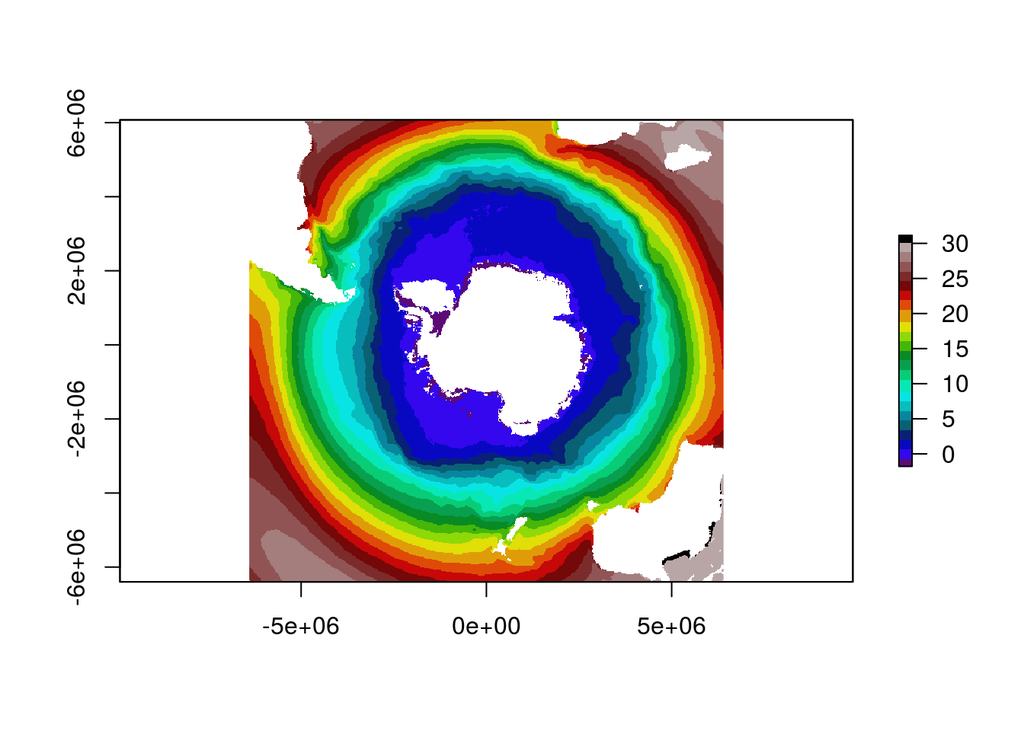

```r
library(palr)
plot(sst, col  = sstPal(24))
```

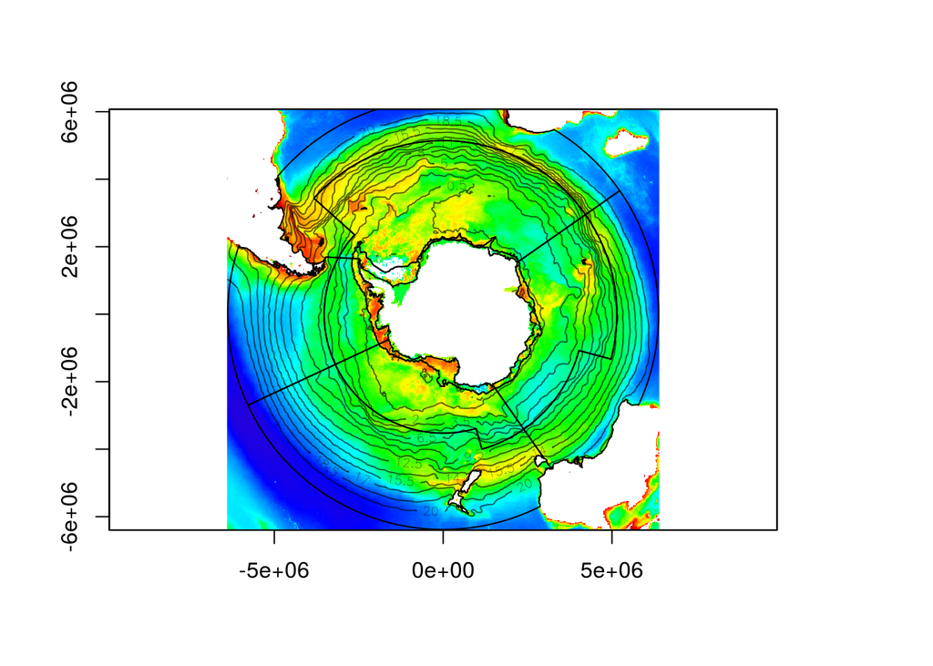

```r
chlpal <- chlPal(palette = TRUE)
plot(chla, col = chlpal$cols, breaks = chlpal$breaks, legend = FALSE)
contour(sst, add = T, levels = seq(-1, 20, by = 1.5), col = rgb(0, 0, 0, 0.6))
library(aceecostats)
plot(spTransform(aes_region_simple, projection(sst)), add = T)
```

## Database construction

The script to recreate the database is https://github.com/AustralianAntarcticDivision/aceecostats/blob/master/inst/workflow/05_chl_sst_25k.R

### Data sources files

The data files used

- MODISA L3 bin daily RRS 4km, converted to Johnson 2013 chlorophyll-a, and summarized by 25km cell into monthly means
- OISST daily 0.25 degree daily sst, masked by in-built ice mask and summarized by 25km cell into monthly means

Missing values in SST only exist where sea ice is masked by the OISST product.

Missing values in CHLA also exist where cloud cover obscured the instrument during the entire month, on the order of 2500-7000 25km cells per month. For these we found the nearest valid value and filled it in. We used nearest-neighbour lookup with the `nabor` package.

### Data preparation

We maintain a collection of daily L3 bin 4km chlorophyll-a data files, with Johnson 2013 chlorophyll pre-calculated. The L3 bins are summarized into 25km cells by bin-centre lookup, transforming the bin centre to Lambert Azimuthal Equal area.

The SST pixels are transformed directly to the 25km cells by raster reprojection on each daily grid.